# Lab 2 - Team

#2.How does the number of ratings depend on the year? Draw a bar chart of the number of reports. Date <- choco$Date Rating <- choco$Rating

[figure not shown]

```r
barplot(choco$Rating,names.arg = choco$Date)
```

#3.Do ratings depend on the cacao percentage of a chocolate bar? Create both numerical and graphical summaries, and explain.

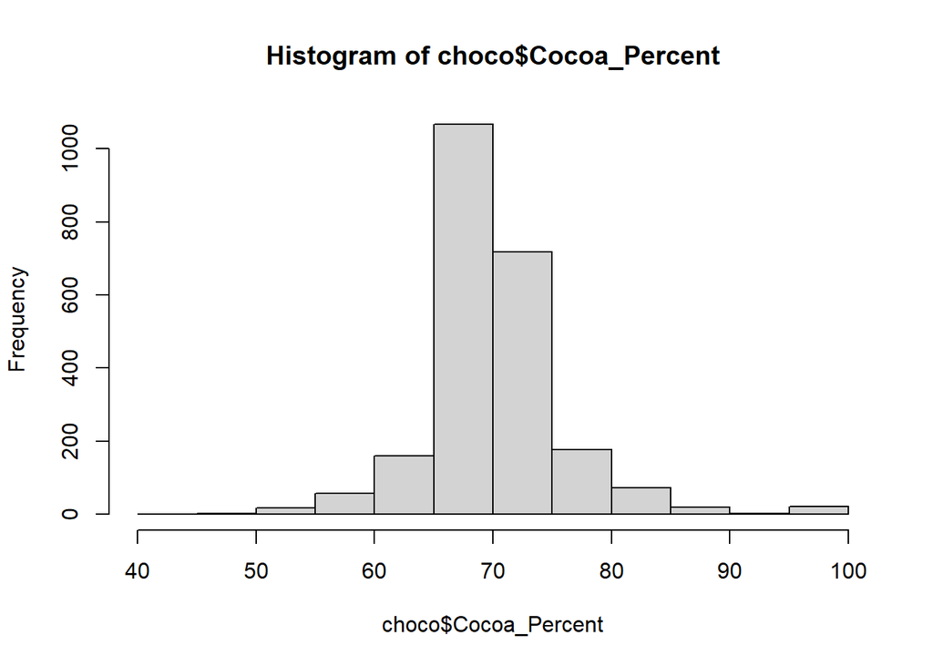

```r
hist(choco$Cocoa_Percent,)
```

```r
percent <- choco$Cocoa_Percent
names(percent) <- choco$Rating
head(sort(percent, decreasing = TRUE), n = 10)
```

```
## 1.75  1.5  1.5  3.5    1  1.5    3    2 1.75 2.75
##  100  100  100  100  100  100  100  100  100  100
```

```r
top10 <- head(sort(percent, decreasing = TRUE), n = 10)
top10
```

```
## 1.75  1.5  1.5  3.5    1  1.5    3    2 1.75 2.75
##  100  100  100  100  100  100  100  100  100  100
```

#average rating for top 10:2.025

```r
head(sort(percent, decreasing = FALSE), n = 10)
```

```
## 2.75 2.75 3.75    2 2.75 2.75  3.5 3.25    3 2.75
##   42   46   50   53   55   55   55   55   55   55
```

```r
bottom10 <- head(sort(percent, decreasing = FALSE), n = 10)
bottom10
```

```
## 2.75 2.75 3.75    2 2.75 2.75  3.5 3.25    3 2.75
##   42   46   50   53   55   55   55   55   55   55
```

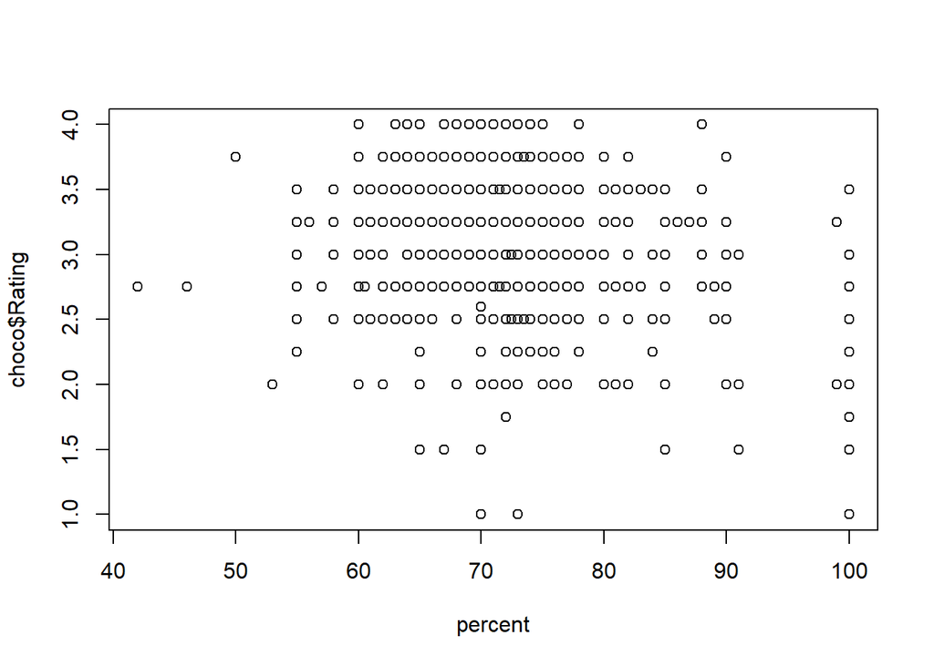

```r
plot(percent, choco$Rating)
```

#Explanation: Through the scatter plot above, it can be infered that most the cocoa percentages that were in between 60% and 80% tend to have the highest ratings.